# Project description.

Prepare a prototype machine learning model for Zifra. The company develops solutions for the efficient operation of industrial enterprises.

The model should predict the recovery factor for gold from gold ore. You have data with extraction and cleaning parameters at your disposal.

The model will help optimize production so as not to launch an enterprise with unprofitable characteristics.

You need:

1. Prepare data;
2. Conduct exploratory data analysis;
3. Build and train the model.

# Data description:

The data is in three files:

gold_recovery_train.csv — training set;

gold_recovery_test.csv — test set;

gold_recovery_full.csv — initial data.

The data is indexed by the date and time of receipt of the information (sign date). Parameters adjacent in time are often similar. Some parameters are not available because they are measured and/or calculated much later. Because of this, the test sample lacks some features that may be in the training one. Also, there are no target features in the test set.

The initial dataset contains the training and test sets with all features.

You have raw data at your disposal: they were simply unloaded from storage. Before you start building a model, check them for correctness according to our instructions.

# 1. Data preparation.

```python
import pandas as pd
from sklearn.model_selection import train_test_split
from sklearn.preprocessing import StandardScaler
from sklearn.linear_model import LinearRegression
from sklearn.tree import DecisionTreeRegressor
from sklearn.ensemble import RandomForestRegressor
from sklearn.metrics import mean_absolute_error
from sklearn.model_selection import cross_val_score
import matplotlib.pyplot as plt
import numpy as np
from sklearn.metrics import make_scorer
import warnings
warnings.filterwarnings('ignore')
```

Let's upload the files and make the 'data' column index in each one.

```python
df = pd.read_csv('/datasets/gold_recovery_full.csv')
df.head()
```

|  | date | final.output.concentrate_ag | final.output.concentrate_pb | final.output.concentrate_sol | final.output.concentrate_au | final.output.recovery | final.output.tail_ag | final.output.tail_pb | final.output.tail_sol | final.output.tail_au | ... | secondary_cleaner.state.floatbank4_a_air | secondary_cleaner.state.floatbank4_a_level | secondary_cleaner.state.floatbank4_b_air | secondary_cleaner.state.floatbank4_b_level | secondary_cleaner.state.floatbank5_a_air | secondary_cleaner.state.floatbank5_a_level | secondary_cleaner.state.floatbank5_b_air | secondary_cleaner.state.floatbank5_b_level | secondary_cleaner.state.floatbank6_a_air | secondary_cleaner.state.floatbank6_a_level |
| --- | --- | --- | --- | --- | --- | --- | --- | --- | --- | --- | --- | --- | --- | --- | --- | --- | --- | --- | --- | --- | --- |
| 0 | 2016-01-15 00:00:00 | 6.055403 | 9.889648 | 5.507324 | 42.192020 | 70.541216 | 10.411962 | 0.895447 | 16.904297 | 2.143149 | ... | 14.016835 | -502.488007 | 12.099931 | -504.715942 | 9.925633 | -498.310211 | 8.079666 | -500.470978 | 14.151341 | -605.841980 |
| 1 | 2016-01-15 01:00:00 | 6.029369 | 9.968944 | 5.257781 | 42.701629 | 69.266198 | 10.462676 | 0.927452 | 16.634514 | 2.224930 | ... | 13.992281 | -505.503262 | 11.950531 | -501.331529 | 10.039245 | -500.169983 | 7.984757 | -500.582168 | 13.998353 | -599.787184 |
| 2 | 2016-01-15 02:00:00 | 6.055926 | 10.213995 | 5.383759 | 42.657501 | 68.116445 | 10.507046 | 0.953716 | 16.208849 | 2.257889 | ... | 14.015015 | -502.520901 | 11.912783 | -501.133383 | 10.070913 | -500.129135 | 8.013877 | -500.517572 | 14.028663 | -601.427363 |
| 3 | 2016-01-15 03:00:00 | 6.047977 | 9.977019 | 4.858634 | 42.689819 | 68.347543 | 10.422762 | 0.883763 | 16.532835 | 2.146849 | ... | 14.036510 | -500.857308 | 11.999550 | -501.193686 | 9.970366 | -499.201640 | 7.977324 | -500.255908 | 14.005551 | -599.996129 |
| 4 | 2016-01-15 04:00:00 | 6.148599 | 10.142511 | 4.939416 | 42.774141 | 66.927016 | 10.360302 | 0.792826 | 16.525686 | 2.055292 | ... | 14.027298 | -499.838632 | 11.953070 | -501.053894 | 9.925709 | -501.686727 | 7.894242 | -500.356035 | 13.996647 | -601.496691 |

5 rows × 87 columns

```python
df = df.set_index('date')
```

```python
df_train = pd.read_csv('/datasets//gold_recovery_train.csv')
df_train.head()
```

|  | date | final.output.concentrate_ag | final.output.concentrate_pb | final.output.concentrate_sol | final.output.concentrate_au | final.output.recovery | final.output.tail_ag | final.output.tail_pb | final.output.tail_sol | final.output.tail_au | ... | secondary_cleaner.state.floatbank4_a_air | secondary_cleaner.state.floatbank4_a_level | secondary_cleaner.state.floatbank4_b_air | secondary_cleaner.state.floatbank4_b_level | secondary_cleaner.state.floatbank5_a_air | secondary_cleaner.state.floatbank5_a_level | secondary_cleaner.state.floatbank5_b_air | secondary_cleaner.state.floatbank5_b_level | secondary_cleaner.state.floatbank6_a_air | secondary_cleaner.state.floatbank6_a_level |
| --- | --- | --- | --- | --- | --- | --- | --- | --- | --- | --- | --- | --- | --- | --- | --- | --- | --- | --- | --- | --- | --- |
| 0 | 2016-01-15 00:00:00 | 6.055403 | 9.889648 | 5.507324 | 42.192020 | 70.541216 | 10.411962 | 0.895447 | 16.904297 | 2.143149 | ... | 14.016835 | -502.488007 | 12.099931 | -504.715942 | 9.925633 | -498.310211 | 8.079666 | -500.470978 | 14.151341 | -605.841980 |
| 1 | 2016-01-15 01:00:00 | 6.029369 | 9.968944 | 5.257781 | 42.701629 | 69.266198 | 10.462676 | 0.927452 | 16.634514 | 2.224930 | ... | 13.992281 | -505.503262 | 11.950531 | -501.331529 | 10.039245 | -500.169983 | 7.984757 | -500.582168 | 13.998353 | -599.787184 |
| 2 | 2016-01-15 02:00:00 | 6.055926 | 10.213995 | 5.383759 | 42.657501 | 68.116445 | 10.507046 | 0.953716 | 16.208849 | 2.257889 | ... | 14.015015 | -502.520901 | 11.912783 | -501.133383 | 10.070913 | -500.129135 | 8.013877 | -500.517572 | 14.028663 | -601.427363 |
| 3 | 2016-01-15 03:00:00 | 6.047977 | 9.977019 | 4.858634 | 42.689819 | 68.347543 | 10.422762 | 0.883763 | 16.532835 | 2.146849 | ... | 14.036510 | -500.857308 | 11.999550 | -501.193686 | 9.970366 | -499.201640 | 7.977324 | -500.255908 | 14.005551 | -599.996129 |
| 4 | 2016-01-15 04:00:00 | 6.148599 | 10.142511 | 4.939416 | 42.774141 | 66.927016 | 10.360302 | 0.792826 | 16.525686 | 2.055292 | ... | 14.027298 | -499.838632 | 11.953070 | -501.053894 | 9.925709 | -501.686727 | 7.894242 | -500.356035 | 13.996647 | -601.496691 |

5 rows × 87 columns

```python
df_train = df_train.set_index('date')
```

```python
df_train.isna().sum()
```

```
final.output.concentrate_ag                     72
final.output.concentrate_pb                     72
final.output.concentrate_sol                   370
final.output.concentrate_au                     71
final.output.recovery                         1521
                                              ...
secondary_cleaner.state.floatbank5_a_level      85
secondary_cleaner.state.floatbank5_b_air        85
secondary_cleaner.state.floatbank5_b_level      84
secondary_cleaner.state.floatbank6_a_air       103
secondary_cleaner.state.floatbank6_a_level      85
Length: 86, dtype: int64
```

```python
df_train.info()
```

```
<class 'pandas.core.frame.DataFrame'>
Index: 16860 entries, 2016-01-15 00:00:00 to 2018-08-18 10:59:59
Data columns (total 86 columns):
final.output.concentrate_ag                           16788 non-null float64
final.output.concentrate_pb                           16788 non-null float64
final.output.concentrate_sol                          16490 non-null float64
final.output.concentrate_au                           16789 non-null float64
final.output.recovery                                 15339 non-null float64
final.output.tail_ag                                  16794 non-null float64
final.output.tail_pb                                  16677 non-null float64
final.output.tail_sol                                 16715 non-null float64
final.output.tail_au                                  16794 non-null float64
primary_cleaner.input.sulfate                         15553 non-null float64
primary_cleaner.input.depressant                      15598 non-null float64
primary_cleaner.input.feed_size                       16860 non-null float64
primary_cleaner.input.xanthate                        15875 non-null float64
primary_cleaner.output.concentrate_ag                 16778 non-null float64
primary_cleaner.output.concentrate_pb                 16502 non-null float64
primary_cleaner.output.concentrate_sol                16224 non-null float64
primary_cleaner.output.concentrate_au                 16778 non-null float64
primary_cleaner.output.tail_ag                        16777 non-null float64
primary_cleaner.output.tail_pb                        16761 non-null float64
primary_cleaner.output.tail_sol                       16579 non-null float64
primary_cleaner.output.tail_au                        16777 non-null float64
primary_cleaner.state.floatbank8_a_air                16820 non-null float64
primary_cleaner.state.floatbank8_a_level              16827 non-null float64
primary_cleaner.state.floatbank8_b_air                16820 non-null float64
primary_cleaner.state.floatbank8_b_level              16833 non-null float64
primary_cleaner.state.floatbank8_c_air                16822 non-null float64
primary_cleaner.state.floatbank8_c_level              16833 non-null float64
primary_cleaner.state.floatbank8_d_air                16821 non-null float64
primary_cleaner.state.floatbank8_d_level              16833 non-null float64
rougher.calculation.sulfate_to_au_concentrate         16833 non-null float64
rougher.calculation.floatbank10_sulfate_to_au_feed    16833 non-null float64
rougher.calculation.floatbank11_sulfate_to_au_feed    16833 non-null float64
rougher.calculation.au_pb_ratio                       15618 non-null float64
rougher.input.feed_ag                                 16778 non-null float64
rougher.input.feed_pb                                 16632 non-null float64
rougher.input.feed_rate                               16347 non-null float64
rougher.input.feed_size                               16443 non-null float64
```

[output cut: 36 more lines]

```
secondary_cleaner.state.floatbank3_a_level            16747 non-null float64
secondary_cleaner.state.floatbank3_b_air              16752 non-null float64
secondary_cleaner.state.floatbank3_b_level            16750 non-null float64
secondary_cleaner.state.floatbank4_a_air              16731 non-null float64
secondary_cleaner.state.floatbank4_a_level            16747 non-null float64
secondary_cleaner.state.floatbank4_b_air              16768 non-null float64
secondary_cleaner.state.floatbank4_b_level            16767 non-null float64
secondary_cleaner.state.floatbank5_a_air              16775 non-null float64
secondary_cleaner.state.floatbank5_a_level            16775 non-null float64
secondary_cleaner.state.floatbank5_b_air              16775 non-null float64
secondary_cleaner.state.floatbank5_b_level            16776 non-null float64
secondary_cleaner.state.floatbank6_a_air              16757 non-null float64
secondary_cleaner.state.floatbank6_a_level            16775 non-null float64
dtypes: float64(86)
memory usage: 11.2+ MB
```

```python
df_test = pd.read_csv('/datasets/gold_recovery_test.csv')
df_test.head()
```

|  | date | primary_cleaner.input.sulfate | primary_cleaner.input.depressant | primary_cleaner.input.feed_size | primary_cleaner.input.xanthate | primary_cleaner.state.floatbank8_a_air | primary_cleaner.state.floatbank8_a_level | primary_cleaner.state.floatbank8_b_air | primary_cleaner.state.floatbank8_b_level | primary_cleaner.state.floatbank8_c_air | ... | secondary_cleaner.state.floatbank4_a_air | secondary_cleaner.state.floatbank4_a_level | secondary_cleaner.state.floatbank4_b_air | secondary_cleaner.state.floatbank4_b_level | secondary_cleaner.state.floatbank5_a_air | secondary_cleaner.state.floatbank5_a_level | secondary_cleaner.state.floatbank5_b_air | secondary_cleaner.state.floatbank5_b_level | secondary_cleaner.state.floatbank6_a_air | secondary_cleaner.state.floatbank6_a_level |
| --- | --- | --- | --- | --- | --- | --- | --- | --- | --- | --- | --- | --- | --- | --- | --- | --- | --- | --- | --- | --- | --- |
| 0 | 2016-09-01 00:59:59 | 210.800909 | 14.993118 | 8.080000 | 1.005021 | 1398.981301 | -500.225577 | 1399.144926 | -499.919735 | 1400.102998 | ... | 12.023554 | -497.795834 | 8.016656 | -501.289139 | 7.946562 | -432.317850 | 4.872511 | -500.037437 | 26.705889 | -499.709414 |
| 1 | 2016-09-01 01:59:59 | 215.392455 | 14.987471 | 8.080000 | 0.990469 | 1398.777912 | -500.057435 | 1398.055362 | -499.778182 | 1396.151033 | ... | 12.058140 | -498.695773 | 8.130979 | -499.634209 | 7.958270 | -525.839648 | 4.878850 | -500.162375 | 25.019940 | -499.819438 |
| 2 | 2016-09-01 02:59:59 | 215.259946 | 12.884934 | 7.786667 | 0.996043 | 1398.493666 | -500.868360 | 1398.860436 | -499.764529 | 1398.075709 | ... | 11.962366 | -498.767484 | 8.096893 | -500.827423 | 8.071056 | -500.801673 | 4.905125 | -499.828510 | 24.994862 | -500.622559 |
| 3 | 2016-09-01 03:59:59 | 215.336236 | 12.006805 | 7.640000 | 0.863514 | 1399.618111 | -498.863574 | 1397.440120 | -499.211024 | 1400.129303 | ... | 12.033091 | -498.350935 | 8.074946 | -499.474407 | 7.897085 | -500.868509 | 4.931400 | -499.963623 | 24.948919 | -498.709987 |
| 4 | 2016-09-01 04:59:59 | 199.099327 | 10.682530 | 7.530000 | 0.805575 | 1401.268123 | -500.808305 | 1398.128818 | -499.504543 | 1402.172226 | ... | 12.025367 | -500.786497 | 8.054678 | -500.397500 | 8.107890 | -509.526725 | 4.957674 | -500.360026 | 25.003331 | -500.856333 |

5 rows × 53 columns

```python
df_test = df_test.set_index('date')
```

```python
df_test.info()
```

```
<class 'pandas.core.frame.DataFrame'>
Index: 5856 entries, 2016-09-01 00:59:59 to 2017-12-31 23:59:59
Data columns (total 52 columns):
primary_cleaner.input.sulfate                 5554 non-null float64
primary_cleaner.input.depressant              5572 non-null float64
primary_cleaner.input.feed_size               5856 non-null float64
primary_cleaner.input.xanthate                5690 non-null float64
primary_cleaner.state.floatbank8_a_air        5840 non-null float64
primary_cleaner.state.floatbank8_a_level      5840 non-null float64
primary_cleaner.state.floatbank8_b_air        5840 non-null float64
primary_cleaner.state.floatbank8_b_level      5840 non-null float64
primary_cleaner.state.floatbank8_c_air        5840 non-null float64
primary_cleaner.state.floatbank8_c_level      5840 non-null float64
primary_cleaner.state.floatbank8_d_air        5840 non-null float64
primary_cleaner.state.floatbank8_d_level      5840 non-null float64
rougher.input.feed_ag                         5840 non-null float64
rougher.input.feed_pb                         5840 non-null float64
rougher.input.feed_rate                       5816 non-null float64
rougher.input.feed_size                       5834 non-null float64
rougher.input.feed_sol                        5789 non-null float64
rougher.input.feed_au                         5840 non-null float64
rougher.input.floatbank10_sulfate             5599 non-null float64
rougher.input.floatbank10_xanthate            5733 non-null float64
rougher.input.floatbank11_sulfate             5801 non-null float64
rougher.input.floatbank11_xanthate            5503 non-null float64
rougher.state.floatbank10_a_air               5839 non-null float64
rougher.state.floatbank10_a_level             5840 non-null float64
rougher.state.floatbank10_b_air               5839 non-null float64
rougher.state.floatbank10_b_level             5840 non-null float64
rougher.state.floatbank10_c_air               5839 non-null float64
rougher.state.floatbank10_c_level             5840 non-null float64
rougher.state.floatbank10_d_air               5839 non-null float64
rougher.state.floatbank10_d_level             5840 non-null float64
rougher.state.floatbank10_e_air               5839 non-null float64
rougher.state.floatbank10_e_level             5840 non-null float64
rougher.state.floatbank10_f_air               5839 non-null float64
rougher.state.floatbank10_f_level             5840 non-null float64
secondary_cleaner.state.floatbank2_a_air      5836 non-null float64
secondary_cleaner.state.floatbank2_a_level    5840 non-null float64
secondary_cleaner.state.floatbank2_b_air      5833 non-null float64
secondary_cleaner.state.floatbank2_b_level    5840 non-null float64
secondary_cleaner.state.floatbank3_a_air      5822 non-null float64
secondary_cleaner.state.floatbank3_a_level    5840 non-null float64
secondary_cleaner.state.floatbank3_b_air      5840 non-null float64
secondary_cleaner.state.floatbank3_b_level    5840 non-null float64
secondary_cleaner.state.floatbank4_a_air      5840 non-null float64
secondary_cleaner.state.floatbank4_a_level    5840 non-null float64
secondary_cleaner.state.floatbank4_b_air      5840 non-null float64
secondary_cleaner.state.floatbank4_b_level    5840 non-null float64
secondary_cleaner.state.floatbank5_a_air      5840 non-null float64
secondary_cleaner.state.floatbank5_a_level    5840 non-null float64
secondary_cleaner.state.floatbank5_b_air      5840 non-null float64
secondary_cleaner.state.floatbank5_b_level    5840 non-null float64
secondary_cleaner.state.floatbank6_a_air      5840 non-null float64
secondary_cleaner.state.floatbank6_a_level    5840 non-null float64
dtypes: float64(52)
memory usage: 2.4+ MB
```

First, let's see that the rough concentrate enrichment efficiency (rougher.output.recovery) is calculated correctly. Calculate it on the training sample and find the MAE between the resulting calculations and the feature value.

To do this, we remove the missing values.

```python
df_train.dropna(subset=['rougher.output.concentrate_au', 'rougher.output.recovery', 'rougher.input.feed_au',
'rougher.output.tail_au'], inplace=True)
```

Now let's calculate the mean absolute deviation (MAE), for this we will use the mean_absolute_error() function.

```python
feed_au = df_train['rougher.input.feed_au']
concentrate_au = df_train['rougher.output.concentrate_au']
tail_au = df_train['rougher.output.tail_au']
recovery = df_train['rougher.output.recovery']
predicted = concentrate_au * (feed_au - tail_au) / feed_au / (concentrate_au - tail_au) * 100
print(mean_absolute_error(recovery, predicted))
```

```
1.0512313043960013e-14
```

After analyzing the features that are not available in the test sample, we see that these are the values: 'rougher.output', 'final.output', 'primary_cleaner.output', 'secondary_cleaner.output' and 'rougher.calculation'. They are online metrics, that is, they are calculated only in a working system with real users, they cannot be calculated from historical data for another model. The remaining columns are present in both tables, which means that they are offline metrics.

Let's preprocess the data. Let's get rid of missing values in the training and test samples.

```python
df_trains = df_train.dropna()
df_trains.head()
```

| date | final.output.concentrate_ag | final.output.concentrate_pb | final.output.concentrate_sol | final.output.concentrate_au | final.output.recovery | final.output.tail_ag | final.output.tail_pb | final.output.tail_sol | final.output.tail_au | primary_cleaner.input.sulfate | ... | secondary_cleaner.state.floatbank4_a_air | secondary_cleaner.state.floatbank4_a_level | secondary_cleaner.state.floatbank4_b_air | secondary_cleaner.state.floatbank4_b_level | secondary_cleaner.state.floatbank5_a_air | secondary_cleaner.state.floatbank5_a_level | secondary_cleaner.state.floatbank5_b_air | secondary_cleaner.state.floatbank5_b_level | secondary_cleaner.state.floatbank6_a_air | secondary_cleaner.state.floatbank6_a_level |
| --- | --- | --- | --- | --- | --- | --- | --- | --- | --- | --- | --- | --- | --- | --- | --- | --- | --- | --- | --- | --- | --- |
| 2016-01-15 00:00:00 | 6.055403 | 9.889648 | 5.507324 | 42.192020 | 70.541216 | 10.411962 | 0.895447 | 16.904297 | 2.143149 | 127.092003 | ... | 14.016835 | -502.488007 | 12.099931 | -504.715942 | 9.925633 | -498.310211 | 8.079666 | -500.470978 | 14.151341 | -605.841980 |
| 2016-01-15 01:00:00 | 6.029369 | 9.968944 | 5.257781 | 42.701629 | 69.266198 | 10.462676 | 0.927452 | 16.634514 | 2.224930 | 125.629232 | ... | 13.992281 | -505.503262 | 11.950531 | -501.331529 | 10.039245 | -500.169983 | 7.984757 | -500.582168 | 13.998353 | -599.787184 |
| 2016-01-15 02:00:00 | 6.055926 | 10.213995 | 5.383759 | 42.657501 | 68.116445 | 10.507046 | 0.953716 | 16.208849 | 2.257889 | 123.819808 | ... | 14.015015 | -502.520901 | 11.912783 | -501.133383 | 10.070913 | -500.129135 | 8.013877 | -500.517572 | 14.028663 | -601.427363 |
| 2016-01-15 03:00:00 | 6.047977 | 9.977019 | 4.858634 | 42.689819 | 68.347543 | 10.422762 | 0.883763 | 16.532835 | 2.146849 | 122.270188 | ... | 14.036510 | -500.857308 | 11.999550 | -501.193686 | 9.970366 | -499.201640 | 7.977324 | -500.255908 | 14.005551 | -599.996129 |
| 2016-01-15 04:00:00 | 6.148599 | 10.142511 | 4.939416 | 42.774141 | 66.927016 | 10.360302 | 0.792826 | 16.525686 | 2.055292 | 117.988169 | ... | 14.027298 | -499.838632 | 11.953070 | -501.053894 | 9.925709 | -501.686727 | 7.894242 | -500.356035 | 13.996647 | -601.496691 |

5 rows × 86 columns

```python
df_train.ffill()
```

| date | final.output.concentrate_ag | final.output.concentrate_pb | final.output.concentrate_sol | final.output.concentrate_au | final.output.recovery | final.output.tail_ag | final.output.tail_pb | final.output.tail_sol | final.output.tail_au | primary_cleaner.input.sulfate | ... | secondary_cleaner.state.floatbank4_a_air | secondary_cleaner.state.floatbank4_a_level | secondary_cleaner.state.floatbank4_b_air | secondary_cleaner.state.floatbank4_b_level | secondary_cleaner.state.floatbank5_a_air | secondary_cleaner.state.floatbank5_a_level | secondary_cleaner.state.floatbank5_b_air | secondary_cleaner.state.floatbank5_b_level | secondary_cleaner.state.floatbank6_a_air | secondary_cleaner.state.floatbank6_a_level |
| --- | --- | --- | --- | --- | --- | --- | --- | --- | --- | --- | --- | --- | --- | --- | --- | --- | --- | --- | --- | --- | --- |
| 2016-01-15 00:00:00 | 6.055403 | 9.889648 | 5.507324 | 42.192020 | 70.541216 | 10.411962 | 0.895447 | 16.904297 | 2.143149 | 127.092003 | ... | 14.016835 | -502.488007 | 12.099931 | -504.715942 | 9.925633 | -498.310211 | 8.079666 | -500.470978 | 14.151341 | -605.841980 |
| 2016-01-15 01:00:00 | 6.029369 | 9.968944 | 5.257781 | 42.701629 | 69.266198 | 10.462676 | 0.927452 | 16.634514 | 2.224930 | 125.629232 | ... | 13.992281 | -505.503262 | 11.950531 | -501.331529 | 10.039245 | -500.169983 | 7.984757 | -500.582168 | 13.998353 | -599.787184 |
| 2016-01-15 02:00:00 | 6.055926 | 10.213995 | 5.383759 | 42.657501 | 68.116445 | 10.507046 | 0.953716 | 16.208849 | 2.257889 | 123.819808 | ... | 14.015015 | -502.520901 | 11.912783 | -501.133383 | 10.070913 | -500.129135 | 8.013877 | -500.517572 | 14.028663 | -601.427363 |
| 2016-01-15 03:00:00 | 6.047977 | 9.977019 | 4.858634 | 42.689819 | 68.347543 | 10.422762 | 0.883763 | 16.532835 | 2.146849 | 122.270188 | ... | 14.036510 | -500.857308 | 11.999550 | -501.193686 | 9.970366 | -499.201640 | 7.977324 | -500.255908 | 14.005551 | -599.996129 |
| 2016-01-15 04:00:00 | 6.148599 | 10.142511 | 4.939416 | 42.774141 | 66.927016 | 10.360302 | 0.792826 | 16.525686 | 2.055292 | 117.988169 | ... | 14.027298 | -499.838632 | 11.953070 | -501.053894 | 9.925709 | -501.686727 | 7.894242 | -500.356035 | 13.996647 | -601.496691 |
| ... | ... | ... | ... | ... | ... | ... | ... | ... | ... | ... | ... | ... | ... | ... | ... | ... | ... | ... | ... | ... | ... |
| 2018-08-18 06:59:59 | 3.224920 | 11.356233 | 6.803482 | 46.713954 | 73.755150 | 8.769645 | 3.141541 | 10.403181 | 1.529220 | 123.381787 | ... | 23.031497 | -501.167942 | 20.007571 | -499.740028 | 18.006038 | -499.834374 | 13.001114 | -500.155694 | 20.007840 | -501.296428 |
| 2018-08-18 07:59:59 | 3.195978 | 11.349355 | 6.862249 | 46.866780 | 69.049291 | 8.897321 | 3.130493 | 10.549470 | 1.612542 | 120.878188 | ... | 22.960095 | -501.612783 | 20.035660 | -500.251357 | 17.998535 | -500.395178 | 12.954048 | -499.895163 | 19.968498 | -501.041608 |
| 2018-08-18 08:59:59 | 3.109998 | 11.434366 | 6.886013 | 46.795691 | 67.002189 | 8.529606 | 2.911418 | 11.115147 | 1.596616 | 105.666118 | ... | 23.015718 | -501.711599 | 19.951231 | -499.857027 | 18.019543 | -500.451156 | 13.023431 | -499.914391 | 19.990885 | -501.518452 |
| 2018-08-18 09:59:59 | 3.367241 | 11.625587 | 6.799433 | 46.408188 | 65.523246 | 8.777171 | 2.819214 | 10.463847 | 1.602879 | 98.880538 | ... | 23.024963 | -501.153409 | 20.054122 | -500.314711 | 17.979515 | -499.272871 | 12.992404 | -499.976268 | 20.013986 | -500.625471 |
| 2018-08-18 10:59:59 | 3.598375 | 11.737832 | 6.717509 | 46.299438 | 70.281454 | 8.406690 | 2.517518 | 10.652193 | 1.389434 | 95.248427 | ... | 23.018622 | -500.492702 | 20.020205 | -500.220296 | 17.963512 | -499.939490 | 12.990306 | -500.080993 | 19.990336 | -499.191575 |

14287 rows × 86 columns

```python
df_tests = df_test.dropna()
```

```python
df_test.ffill()
```

| date | primary_cleaner.input.sulfate | primary_cleaner.input.depressant | primary_cleaner.input.feed_size | primary_cleaner.input.xanthate | primary_cleaner.state.floatbank8_a_air | primary_cleaner.state.floatbank8_a_level | primary_cleaner.state.floatbank8_b_air | primary_cleaner.state.floatbank8_b_level | primary_cleaner.state.floatbank8_c_air | primary_cleaner.state.floatbank8_c_level | ... | secondary_cleaner.state.floatbank4_a_air | secondary_cleaner.state.floatbank4_a_level | secondary_cleaner.state.floatbank4_b_air | secondary_cleaner.state.floatbank4_b_level | secondary_cleaner.state.floatbank5_a_air | secondary_cleaner.state.floatbank5_a_level | secondary_cleaner.state.floatbank5_b_air | secondary_cleaner.state.floatbank5_b_level | secondary_cleaner.state.floatbank6_a_air | secondary_cleaner.state.floatbank6_a_level |
| --- | --- | --- | --- | --- | --- | --- | --- | --- | --- | --- | --- | --- | --- | --- | --- | --- | --- | --- | --- | --- | --- |
| 2016-09-01 00:59:59 | 210.800909 | 14.993118 | 8.080000 | 1.005021 | 1398.981301 | -500.225577 | 1399.144926 | -499.919735 | 1400.102998 | -500.704369 | ... | 12.023554 | -497.795834 | 8.016656 | -501.289139 | 7.946562 | -432.317850 | 4.872511 | -500.037437 | 26.705889 | -499.709414 |
| 2016-09-01 01:59:59 | 215.392455 | 14.987471 | 8.080000 | 0.990469 | 1398.777912 | -500.057435 | 1398.055362 | -499.778182 | 1396.151033 | -499.240168 | ... | 12.058140 | -498.695773 | 8.130979 | -499.634209 | 7.958270 | -525.839648 | 4.878850 | -500.162375 | 25.019940 | -499.819438 |
| 2016-09-01 02:59:59 | 215.259946 | 12.884934 | 7.786667 | 0.996043 | 1398.493666 | -500.868360 | 1398.860436 | -499.764529 | 1398.075709 | -502.151509 | ... | 11.962366 | -498.767484 | 8.096893 | -500.827423 | 8.071056 | -500.801673 | 4.905125 | -499.828510 | 24.994862 | -500.622559 |
| 2016-09-01 03:59:59 | 215.336236 | 12.006805 | 7.640000 | 0.863514 | 1399.618111 | -498.863574 | 1397.440120 | -499.211024 | 1400.129303 | -498.355873 | ... | 12.033091 | -498.350935 | 8.074946 | -499.474407 | 7.897085 | -500.868509 | 4.931400 | -499.963623 | 24.948919 | -498.709987 |
| 2016-09-01 04:59:59 | 199.099327 | 10.682530 | 7.530000 | 0.805575 | 1401.268123 | -500.808305 | 1398.128818 | -499.504543 | 1402.172226 | -500.810606 | ... | 12.025367 | -500.786497 | 8.054678 | -500.397500 | 8.107890 | -509.526725 | 4.957674 | -500.360026 | 25.003331 | -500.856333 |
| ... | ... | ... | ... | ... | ... | ... | ... | ... | ... | ... | ... | ... | ... | ... | ... | ... | ... | ... | ... | ... | ... |
| 2017-12-31 19:59:59 | 173.957757 | 15.963399 | 8.070000 | 0.896701 | 1401.930554 | -499.728848 | 1401.441445 | -499.193423 | 1399.810313 | -499.599127 | ... | 13.995957 | -500.157454 | 12.069155 | -499.673279 | 7.977259 | -499.516126 | 5.933319 | -499.965973 | 8.987171 | -499.755909 |
| 2017-12-31 20:59:59 | 172.910270 | 16.002605 | 8.070000 | 0.896519 | 1447.075722 | -494.716823 | 1448.851892 | -465.963026 | 1443.890424 | -503.587739 | ... | 16.749781 | -496.031539 | 13.365371 | -499.122723 | 9.288553 | -496.892967 | 7.372897 | -499.942956 | 8.986832 | -499.903761 |
| 2017-12-31 21:59:59 | 171.135718 | 15.993669 | 8.070000 | 1.165996 | 1498.836182 | -501.770403 | 1499.572353 | -495.516347 | 1502.749213 | -520.667442 | ... | 19.994130 | -499.791312 | 15.101425 | -499.936252 | 10.989181 | -498.347898 | 9.020944 | -500.040448 | 8.982038 | -497.789882 |
| 2017-12-31 22:59:59 | 179.697158 | 15.438979 | 8.070000 | 1.501068 | 1498.466243 | -500.483984 | 1497.986986 | -519.200340 | 1496.569047 | -487.479567 | ... | 19.958760 | -499.958750 | 15.026853 | -499.723143 | 11.011607 | -499.985046 | 9.009783 | -499.937902 | 9.012660 | -500.154284 |
| 2017-12-31 23:59:59 | 181.556856 | 14.995850 | 8.070000 | 1.623454 | 1498.096303 | -499.796922 | 1501.743791 | -505.146931 | 1499.535978 | -492.428226 | ... | 20.034715 | -500.728588 | 14.914199 | -499.948518 | 10.986607 | -500.658027 | 8.989497 | -500.337588 | 8.988632 | -500.764937 |

5856 rows × 52 columns

```python
df_trains[df_trains['rougher.output.recovery'] == 0]
```

| date | final.output.concentrate_ag | final.output.concentrate_pb | final.output.concentrate_sol | final.output.concentrate_au | final.output.recovery | final.output.tail_ag | final.output.tail_pb | final.output.tail_sol | final.output.tail_au | primary_cleaner.input.sulfate | ... | secondary_cleaner.state.floatbank4_a_air | secondary_cleaner.state.floatbank4_a_level | secondary_cleaner.state.floatbank4_b_air | secondary_cleaner.state.floatbank4_b_level | secondary_cleaner.state.floatbank5_a_air | secondary_cleaner.state.floatbank5_a_level | secondary_cleaner.state.floatbank5_b_air | secondary_cleaner.state.floatbank5_b_level | secondary_cleaner.state.floatbank6_a_air | secondary_cleaner.state.floatbank6_a_level |
| --- | --- | --- | --- | --- | --- | --- | --- | --- | --- | --- | --- | --- | --- | --- | --- | --- | --- | --- | --- | --- | --- |
| 2016-01-16 21:00:00 | 4.566664 | 10.406178 | 4.588698 | 46.614456 | 68.403877 | 10.705777 | 1.509070 | 17.875134 | 2.509776 | 131.251366 | ... | 14.025588 | -550.404242 | 12.028925 | -550.570104 | 10.052072 | -500.797905 | 7.984500 | -499.581046 | 11.982025 | -599.161228 |
| 2016-01-16 22:00:00 | 4.577832 | 10.691605 | 5.274175 | 46.250638 | 70.675633 | 10.728531 | 1.641216 | 18.349339 | 2.540843 | 141.184039 | ... | 14.094808 | -550.676337 | 12.004728 | -550.496522 | 9.953139 | -500.330920 | 8.012074 | -500.133530 | 11.975316 | -598.839683 |
| 2016-01-17 03:00:00 | 5.759800 | 9.537415 | 3.997737 | 45.267942 | 68.638723 | 10.623064 | 1.217058 | 16.072705 | 2.471388 | 118.895031 | ... | 14.164342 | -552.959690 | 11.917980 | -549.417320 | 10.016315 | -497.644975 | 7.999080 | -500.112143 | 12.043030 | -599.630112 |
| 2016-01-17 04:00:00 | 5.807253 | 10.439505 | 6.512951 | 43.237493 | 72.136712 | 10.518407 | 1.336890 | 17.750367 | 2.323883 | 126.796059 | ... | 14.097072 | -549.292129 | 12.000525 | -550.306171 | 9.925991 | -501.985618 | 7.948277 | -500.060988 | 12.005620 | -601.746110 |
| 2016-02-18 20:00:00 | 8.478624 | 11.303437 | 10.547473 | 35.776254 | 80.041038 | 12.958362 | 2.369492 | 9.839622 | 3.066451 | 223.382947 | ... | 23.709602 | -412.029336 | 22.639733 | -412.896304 | 25.021629 | -428.537556 | 21.011542 | -400.287375 | 30.004867 | -396.683519 |
| ... | ... | ... | ... | ... | ... | ... | ... | ... | ... | ... | ... | ... | ... | ... | ... | ... | ... | ... | ... | ... | ... |
| 2018-02-08 08:59:59 | 4.295944 | 9.047270 | 10.158392 | 50.095787 | 75.434112 | 10.526101 | 1.067729 | 13.041430 | 2.457288 | 89.761854 | ... | 19.975919 | -498.544229 | 15.055408 | -499.772455 | 11.074477 | -499.489770 | 8.967751 | -499.740724 | 10.995065 | -499.680472 |
| 2018-02-08 09:59:59 | 4.269068 | 8.434313 | 9.634574 | 46.514744 | 77.363789 | 10.441324 | 1.100272 | 12.907265 | 2.524209 | 94.625471 | ... | 19.995312 | -501.422625 | 15.061346 | -500.215616 | 11.023662 | -501.176999 | 8.949878 | -500.263227 | 11.018219 | -500.868268 |
| 2018-02-08 10:59:59 | 4.912996 | 8.757087 | 8.908876 | 44.463884 | 76.091062 | 11.260668 | 1.456670 | 12.996270 | 2.782712 | 104.085931 | ... | 19.908923 | -498.632480 | 15.067284 | -499.674636 | 10.971864 | -498.948495 | 9.003349 | -499.867722 | 10.991802 | -498.783215 |
| 2018-02-08 23:59:59 | 5.802428 | 9.995077 | 9.086919 | 46.995437 | 77.875777 | 9.791625 | 0.844802 | 12.942014 | 1.993125 | 89.263022 | ... | 19.957912 | -499.436774 | 15.033817 | -500.059081 | 10.905149 | -499.117140 | 8.958055 | -499.770528 | 10.967687 | -499.296938 |
| 2018-02-09 00:59:59 | 5.380257 | 9.748785 | 9.024721 | 47.788968 | 75.843540 | 9.418202 | 0.763430 | 12.991472 | 1.885333 | 79.497837 | ... | 20.011013 | -499.852067 | 15.033800 | -500.080777 | 10.981418 | -500.942639 | 9.081741 | -499.700289 | 10.982919 | -501.516158 |

205 rows × 86 columns

```python
df_trains = df_trains.drop(df_trains[df_trains['rougher.output.recovery'] == 0].index)
```

```python
df_trains[df_trains['final.output.recovery'] == 0]
```

| date | final.output.concentrate_ag | final.output.concentrate_pb | final.output.concentrate_sol | final.output.concentrate_au | final.output.recovery | final.output.tail_ag | final.output.tail_pb | final.output.tail_sol | final.output.tail_au | primary_cleaner.input.sulfate | ... | secondary_cleaner.state.floatbank4_a_air | secondary_cleaner.state.floatbank4_a_level | secondary_cleaner.state.floatbank4_b_air | secondary_cleaner.state.floatbank4_b_level | secondary_cleaner.state.floatbank5_a_air | secondary_cleaner.state.floatbank5_a_level | secondary_cleaner.state.floatbank5_b_air | secondary_cleaner.state.floatbank5_b_level | secondary_cleaner.state.floatbank6_a_air | secondary_cleaner.state.floatbank6_a_level |
| --- | --- | --- | --- | --- | --- | --- | --- | --- | --- | --- | --- | --- | --- | --- | --- | --- | --- | --- | --- | --- | --- |
| 2016-02-13 11:00:00 | 0.0 | 0.0 | 0.0 | 0.0 | 0.0 | 8.894029 | 0.843584 | 15.417342 | 1.779052 | 133.610147 | ... | 21.991762 | -399.587122 | 21.988937 | -401.366408 | 22.995012 | -399.370680 | 20.966863 | -399.308354 | 24.987274 | -399.619808 |
| 2016-03-11 10:00:00 | 0.0 | 0.0 | 0.0 | 0.0 | 0.0 | 10.817313 | 1.462800 | 16.407607 | 2.984504 | 111.502432 | ... | 11.979352 | -453.431061 | 12.003445 | -450.179844 | 11.982937 | -449.856468 | 9.927727 | -450.521700 | 19.971682 | -500.685521 |
| 2016-03-11 11:00:00 | 0.0 | 0.0 | 0.0 | 0.0 | 0.0 | 10.436792 | 1.207636 | 17.800392 | 2.747294 | 110.586754 | ... | 12.034636 | -446.590944 | 12.130405 | -449.684812 | 11.844983 | -450.881424 | 9.916784 | -449.542871 | 20.004767 | -500.137068 |
| 2016-03-11 12:00:00 | 0.0 | 0.0 | 0.0 | 0.0 | 0.0 | 10.637073 | 1.405778 | 17.195897 | 2.791440 | 104.202288 | ... | 12.016716 | -496.613149 | 12.055535 | -496.908551 | 12.091144 | -496.404140 | 9.976074 | -496.783155 | 19.921634 | -500.769011 |
| 2016-03-11 13:00:00 | 0.0 | 0.0 | 0.0 | 0.0 | 0.0 | 10.530320 | 1.461550 | 17.556860 | 2.682127 | 102.438023 | ... | 11.993898 | -500.427824 | 12.083824 | -500.162537 | 12.078809 | -499.903743 | 10.075259 | -499.540325 | 20.039788 | -499.932405 |
| 2016-05-01 23:59:59 | 0.0 | 0.0 | 0.0 | 0.0 | 0.0 | 2.229996 | 0.439314 | 2.996147 | 1.049438 | 72.129802 | ... | 14.957055 | -522.627263 | 13.060565 | -502.673001 | 8.851882 | -503.279765 | 9.037939 | -500.400661 | 15.999356 | -509.449510 |
| 2016-05-02 00:59:59 | 0.0 | 0.0 | 0.0 | 0.0 | 0.0 | 8.816376 | 1.692314 | 12.001629 | 3.949153 | 108.473832 | ... | 15.032195 | -498.930340 | 13.051205 | -502.405376 | 8.972976 | -498.876974 | 9.070907 | -499.455708 | 16.026009 | -492.939580 |
| 2016-05-11 01:59:59 | 0.0 | 0.0 | 0.0 | 0.0 | 0.0 | 7.567252 | 1.991327 | 12.977099 | 3.170143 | 156.570204 | ... | 14.005274 | -500.345401 | 12.087124 | -500.180957 | 11.025995 | -501.002632 | 6.093285 | -500.452445 | 20.023462 | -500.365653 |
| 2016-08-15 23:59:59 | 0.0 | 0.0 | 0.0 | 0.0 | 0.0 | 10.796039 | 2.582106 | 11.105074 | 3.231677 | 175.874707 | ... | 17.879648 | -399.935545 | 10.012001 | -399.585744 | 15.086155 | -396.783371 | 4.961631 | -400.638627 | 23.037383 | -498.990216 |
| 2016-08-26 20:59:59 | 0.0 | 0.0 | 0.0 | 0.0 | 0.0 | 3.697301 | 1.378608 | 3.952049 | 2.579844 | 57.318476 | ... | 15.969769 | -499.841050 | 9.972046 | -499.963654 | 9.913467 | -501.698056 | 5.011314 | -500.390274 | 24.919704 | -502.454004 |
| 2017-01-02 16:59:59 | 0.0 | 0.0 | 0.0 | 0.0 | 0.0 | 10.512889 | 1.950646 | 11.188996 | 2.508362 | 117.597845 | ... | 17.012398 | -498.615208 | 14.961553 | -473.509616 | 17.395327 | -499.938041 | 8.054456 | -500.574345 | 19.972880 | -601.259265 |
| 2017-01-02 17:59:59 | 0.0 | 0.0 | 0.0 | 0.0 | 0.0 | 9.955941 | 1.935196 | 11.133852 | 2.797546 | 81.952138 | ... | 16.983206 | -501.381053 | 14.910639 | -497.866523 | 17.070479 | -496.127166 | 8.045207 | -470.953271 | 20.014482 | -591.060032 |
| 2017-01-02 18:59:59 | 0.0 | 0.0 | 0.0 | 0.0 | 0.0 | 10.106171 | 1.712132 | 11.092376 | 2.385774 | 100.770029 | ... | 16.980482 | -500.861399 | 14.999956 | -499.649898 | 17.173301 | -504.678878 | 8.077081 | -484.275794 | 19.991623 | -609.490127 |
| 2017-01-18 14:59:59 | 0.0 | 0.0 | 0.0 | 0.0 | 0.0 | 7.804423 | 3.130217 | 5.586386 | 3.420555 | 113.746848 | ... | 13.987760 | -501.555110 | 13.876556 | -500.025438 | -0.178880 | -491.880038 | 8.035219 | -481.808531 | 19.941542 | -595.360820 |
| 2017-01-18 15:59:59 | 0.0 | 0.0 | 0.0 | 0.0 | 0.0 | 4.990116 | 2.905931 | 5.256589 | 4.213483 | 74.575893 | ... | 14.002255 | -500.944994 | 13.993990 | -499.556599 | -0.173919 | -446.036106 | 3.145675 | -240.872031 | 2.319944 | -642.122184 |
| 2017-01-26 09:59:59 | 0.0 | 0.0 | 0.0 | 0.0 | 0.0 | 10.617218 | 2.747829 | 9.417774 | 2.990722 | 122.924985 | ... | 20.996782 | -501.414482 | 21.072661 | -499.762327 | 22.977603 | -499.840145 | 20.017758 | -499.845860 | 25.001965 | -599.982239 |
| 2017-01-26 10:59:59 | 0.0 | 0.0 | 0.0 | 0.0 | 0.0 | 10.864712 | 2.841514 | 9.153641 | 3.115444 | 123.037098 | ... | 21.011390 | -499.502514 | 21.026886 | -499.684250 | 23.013882 | -499.773163 | 19.981647 | -500.137454 | 25.006088 | -600.019283 |
| 2017-02-24 03:59:59 | 0.0 | 0.0 | 0.0 | 0.0 | 0.0 | 1.764912 | 0.620707 | 1.132730 | 0.619892 | 169.999134 | ... | 25.023822 | -401.065646 | 23.026662 | -400.510308 | 23.023228 | -451.347752 | 20.007511 | -450.038643 | 25.008392 | -500.220216 |
| 2017-03-28 02:59:59 | 0.0 | 0.0 | 0.0 | 0.0 | 0.0 | 6.052901 | 1.855451 | 6.201678 | 2.423505 | 163.446613 | ... | 25.031117 | -397.385023 | 23.047137 | -399.868919 | 29.144954 | -449.497572 | 24.036333 | -450.062637 | 25.004345 | -497.467197 |
| 2017-04-23 15:59:59 | 0.0 | 0.0 | 0.0 | 0.0 | 0.0 | 8.156377 | 2.846728 | 11.214544 | 2.668218 | 127.387145 | ... | 25.022417 | -401.038000 | 23.022316 | -400.035835 | 26.034525 | -450.185761 | 24.013252 | -450.093931 | 29.985963 | -500.076336 |
| 2017-04-23 16:59:59 | 0.0 | 0.0 | 0.0 | 0.0 | 0.0 | 8.128279 | 2.836579 | 10.817374 | 2.557334 | 124.180230 | ... | 25.003407 | -400.114296 | 22.976075 | -399.401191 | 26.003582 | -449.323595 | 24.009039 | -449.969615 | 30.007134 | -499.524684 |
| 2017-04-23 17:59:59 | 0.0 | 0.0 | 0.0 | 0.0 | 0.0 | 8.103931 | 2.747705 | 10.788530 | 2.550075 | 133.815810 | ... | 25.014879 | -399.528536 | 23.021336 | -400.788116 | 25.986338 | -451.070811 | 23.997589 | -449.992990 | 30.014246 | -500.261487 |
| 2017-04-23 18:59:59 | 0.0 | 0.0 | 0.0 | 0.0 | 0.0 | 8.304655 | 2.890794 | 11.387238 | 2.746293 | 122.431122 | ... | 25.006433 | -402.214224 | 22.972691 | -399.623048 | 25.985947 | -450.184325 | 24.023299 | -450.107963 | 29.989302 | -499.837103 |
| 2017-04-23 19:59:59 | 0.0 | 0.0 | 0.0 | 0.0 | 0.0 | 8.326885 | 3.056401 | 10.965152 | 2.801452 | 122.960314 | ... | 24.981659 | -399.351624 | 22.992010 | -399.950198 | 26.026115 | -449.768130 | 24.007241 | -450.263454 | 30.004095 | -499.921109 |
| 2017-05-23 19:59:59 | 0.0 | 0.0 | 0.0 | 0.0 | 0.0 | 6.045862 | 2.572548 | 5.979258 | 3.673219 | 141.211087 | ... | 24.973358 | -498.408784 | 23.015481 | -503.847471 | 26.000855 | -499.736015 | 23.934192 | -499.760094 | 17.989344 | -502.178010 |
| 2017-07-24 13:59:59 | 0.0 | 0.0 | 0.0 | 0.0 | 0.0 | 7.685263 | 2.708151 | 10.191240 | 2.301790 | 102.152515 | ... | 5.157853 | -799.709069 | 4.904193 | -799.889113 | 12.027372 | -493.246532 | 7.672037 | -497.898119 | 12.381912 | -504.537397 |
| 2017-07-26 03:59:59 | 0.0 | 0.0 | 0.0 | 0.0 | 0.0 | 7.074876 | 3.211672 | 11.439958 | 3.660732 | 131.166475 | ... | 12.961509 | -500.559617 | 9.933130 | -380.153762 | 16.030213 | -500.482032 | 10.001274 | -500.142881 | 14.996052 | -500.206741 |
| 2017-07-26 04:59:59 | 0.0 | 0.0 | 0.0 | 0.0 | 0.0 | 6.928070 | 3.158062 | 11.352802 | 3.485946 | 121.419372 | ... | 12.945183 | -498.694819 | 9.916742 | -379.989325 | 15.965493 | -500.537624 | 10.004768 | -500.178703 | 14.985647 | -499.120826 |

28 rows × 86 columns

```python
df_trains = df_trains.drop(df_trains[df_trains['final.output.recovery'] == 0].index)
```

### Conclusion:

Then we got rid of the missing values and removed the zero values in the columns we need for further work.

# 2. Data analysis.

Let's see how the concentration of metals (Au, Ag, Pb) changes at different stages of purification. Draw a graph of the concentration of each substance at each stage.

Chart for Au (gold).

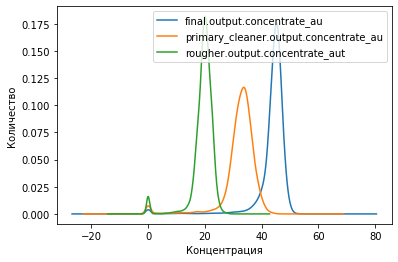

```python
def compare(df_train):
    df_train['final.output.concentrate_au'].plot.kde()
    df_train['primary_cleaner.output.concentrate_au'].plot.kde()
    df_train['rougher.output.concentrate_au'].plot.kde()
    plt.legend(['final.output.concentrate_au', 'primary_cleaner.output.concentrate_au', 'rougher.output.concentrate_aut'])
    plt.xlabel("Концентрация")
    plt.ylabel("Количество")
compare(df_train)
```

We see that at each stage the concentration of gold increases.

Graph for Ag (silver).

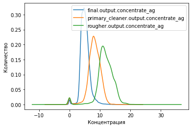

```python
def compare(df_train):
    df_train['final.output.concentrate_ag'].plot.kde()
    df_train['primary_cleaner.output.concentrate_ag'].plot.kde()
    df_train['rougher.output.concentrate_ag'].plot.kde()
    plt.legend(['final.output.concentrate_ag', 'primary_cleaner.output.concentrate_ag', 'rougher.output.concentrate_ag'])
    plt.xlabel("Концентрация")
    plt.ylabel("Количество")
compare(df_train)
```

We see that at each stage the concentration of silver decreases.

Graph for Pb (lead).

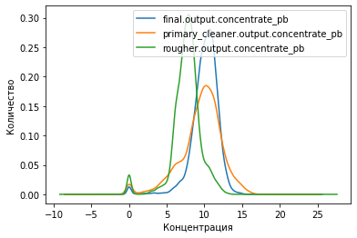

```python
def compare(df_train):
    df_train['final.output.concentrate_pb'].plot.kde()
    df_train['primary_cleaner.output.concentrate_pb'].plot.kde()
    df_train['rougher.output.concentrate_pb'].plot.kde()
    plt.legend(['final.output.concentrate_pb', 'primary_cleaner.output.concentrate_pb', 'rougher.output.concentrate_pb'])
    plt.xlabel("Концентрация")
    plt.ylabel("Количество")
compare(df_train)
```

We see that the lead concentration increases from the flotation stage (rougher) to the primary cleaning stage (primary_cleaner). Next comes the averaging of the quantity, the concentration does not increase on the final characteristics.

Let's compare the size distributions of raw material granules on the training and test samples (if the distributions are very different from each other, then the model estimate will be incorrect).

We will build a schedule for the distribution of raw material granules before each stage.

#### Schedule for stage 1 (flotation):

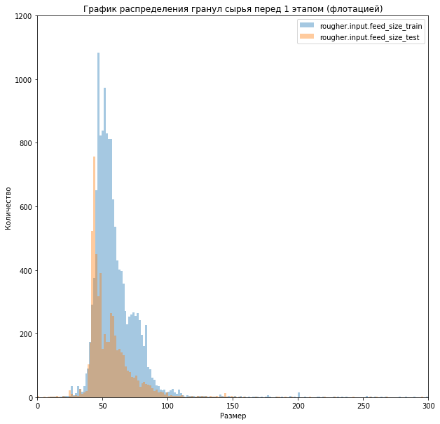

```python
plt.figure(figsize=[10,10])

plt.hist(df_train['rougher.input.feed_size'], bins=300, label = 'rougher.input.feed_size_train', alpha=0.4)
plt.hist(df_test['rougher.input.feed_size'], bins=300, label = 'rougher.input.feed_size_test', alpha=0.4)

plt.xlim([0, 300])
plt.ylim([0, 1200])
plt.xlabel("Размер")
plt.ylabel("Количество")
plt.title("График распределения гранул сырья перед 1 этапом (флотацией)")
plt.legend()
```

The distribution on the graph is normal, it is shifted to the left on both the training and test sets. There is a long tail to the right, that is, outliers.

#### Schedule for stage 2 (primary cleaning):

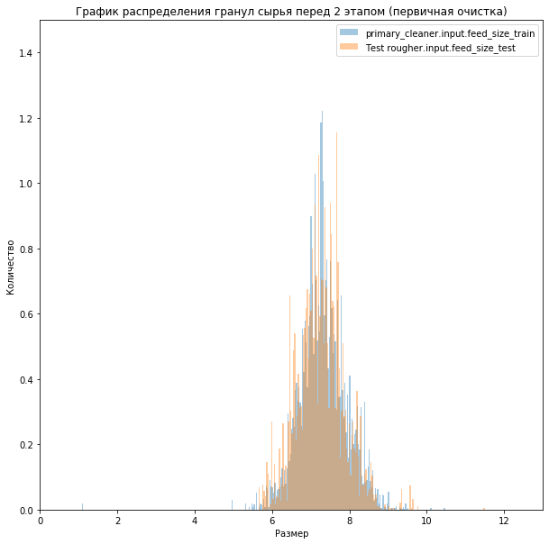

```python
plt.figure(figsize=[10,10])

plt.hist(df_train['primary_cleaner.input.feed_size'], bins=300, label = 'primary_cleaner.input.feed_size_train', alpha=0.4, density=True)
plt.hist(df_test['primary_cleaner.input.feed_size'], bins=300, label = 'Test rougher.input.feed_size_test', alpha=0.4, density=True)

plt.xlim([0, 13])
plt.ylim([0, 1.5])
plt.xlabel("Размер")
plt.ylabel("Количество")
plt.title("График распределения гранул сырья перед 2 этапом (первичная очистка)")
plt.legend()
```

The distribution on the graph is normal, the values of the training and test samples are practically the same.

We investigate the total concentration of all substances at different stages: in raw materials, in rough and final concentrates. If there are anomalous values in the total distribution, then describe the findings and remove the anomalies.

Let's find the total concentration of all substances at different stages (learning sample):

```python
rougher_output_concentrate_sum_train = (df_train['rougher.output.concentrate_au'] +
                                        df_train['rougher.output.concentrate_ag'] +
                                        df_train['rougher.output.concentrate_pb'] +
                                        df_train['rougher.output.concentrate_sol'])

primary_cleaner_output_concentrate_sum_train = (df_train['primary_cleaner.output.concentrate_au'] +
                                                df_train['primary_cleaner.output.concentrate_ag'] +
                                                df_train['primary_cleaner.output.concentrate_pb'] +
                                                df_train['primary_cleaner.output.concentrate_sol'])

final_output_concentrate_sum_trаin = (df_train['final.output.concentrate_au'] +
                                      df_train['final.output.concentrate_ag'] +
                                      df_train['final.output.concentrate_pb'] +
                                      df_train['final.output.concentrate_sol'])
```

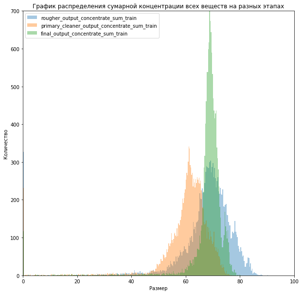

```python
plt.figure(figsize=[10,10])

plt.hist(rougher_output_concentrate_sum_train, bins=300, label = 'rougher_output_concentrate_sum_train', alpha=0.4)
plt.hist(primary_cleaner_output_concentrate_sum_train, bins=300, label = 'primary_cleaner_output_concentrate_sum_train', alpha=0.4)
plt.hist(final_output_concentrate_sum_trаin, bins=300, label = 'final_output_concentrate_sum_trаin', alpha=0.4)



plt.xlim([0, 100])
plt.ylim([0, 700])
plt.xlabel("Размер")
plt.ylabel("Количество")
plt.title("График распределения сумарнoй концентрации всех веществ на разных этапах")
plt.legend()
```

We see that there are a large number of outliers in the value 0. Let's zoom in on this part of the graph.

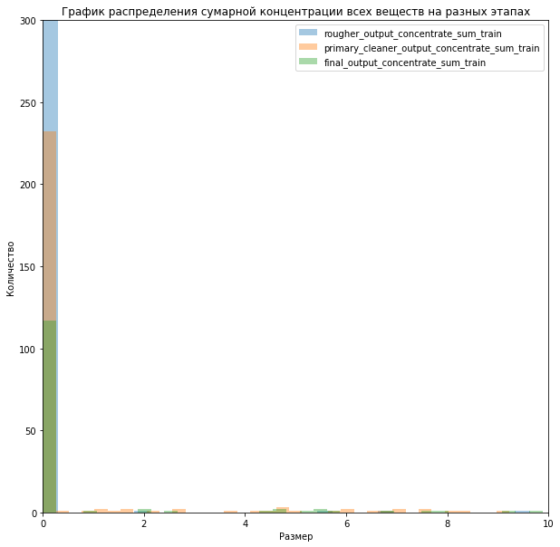

```python
plt.figure(figsize=[10,10])

plt.hist(rougher_output_concentrate_sum_train, bins=300, label = 'rougher_output_concentrate_sum_train', alpha=0.4)
plt.hist(primary_cleaner_output_concentrate_sum_train, bins=300, label = 'primary_cleaner_output_concentrate_sum_train', alpha=0.4)
plt.hist(final_output_concentrate_sum_trаin, bins=300, label = 'final_output_concentrate_sum_trаin', alpha=0.4)



plt.xlim([0, 10])
plt.ylim([0, 300])
plt.xlabel("Размер")
plt.ylabel("Количество")
plt.title("График распределения сумарнoй концентрации всех веществ на разных этапах")
plt.legend()
```

We see that there is a peak at the value of 0 and these are anomalous values that corrupt the data and the only true option is to get rid of them.

```python
df_train = df_train.drop(df_train[df_train['rougher.output.concentrate_au'] == 0].index)
df_train = df_train.drop(df_train[df_train['rougher.output.concentrate_ag'] == 0].index)
df_train = df_train.drop(df_train[df_train['rougher.output.concentrate_pb'] == 0].index)
df_train = df_train.drop(df_train[df_train['rougher.output.concentrate_sol'] == 0].index)
```

```python
df_train = df_train.drop(df_train[df_train['primary_cleaner.output.concentrate_au'] == 0].index)
df_train = df_train.drop(df_train[df_train['primary_cleaner.output.concentrate_ag'] == 0].index)
df_train = df_train.drop(df_train[df_train['primary_cleaner.output.concentrate_pb'] == 0].index)
df_train = df_train.drop(df_train[df_train['primary_cleaner.output.concentrate_sol'] == 0].index)
```

Let's plot the graph again after removing the values equal to 0.

```python
df_train = df_train.drop(df_train[df_train['final.output.concentrate_au'] == 0].index)
df_train = df_train.drop(df_train[df_train['final.output.concentrate_ag'] == 0].index)
df_train = df_train.drop(df_train[df_train['final.output.concentrate_pb'] == 0].index)
df_train = df_train.drop(df_train[df_train['final.output.concentrate_sol'] == 0].index)
```

```python
rougher_output_concentrate_sum_train = (df_train['rougher.output.concentrate_au'] +
                                        df_train['rougher.output.concentrate_ag'] +
                                        df_train['rougher.output.concentrate_pb'] +
                                        df_train['rougher.output.concentrate_sol'])

primary_cleaner_output_concentrate_sum_train = (df_train['primary_cleaner.output.concentrate_au'] +
                                                df_train['primary_cleaner.output.concentrate_ag'] +
                                                df_train['primary_cleaner.output.concentrate_pb'] +
                                                df_train['primary_cleaner.output.concentrate_sol'])

final_output_concentrate_sum_trаin = (df_train['final.output.concentrate_au'] +
                                      df_train['final.output.concentrate_ag'] +
                                      df_train['final.output.concentrate_pb'] +
                                      df_train['final.output.concentrate_sol'])
```

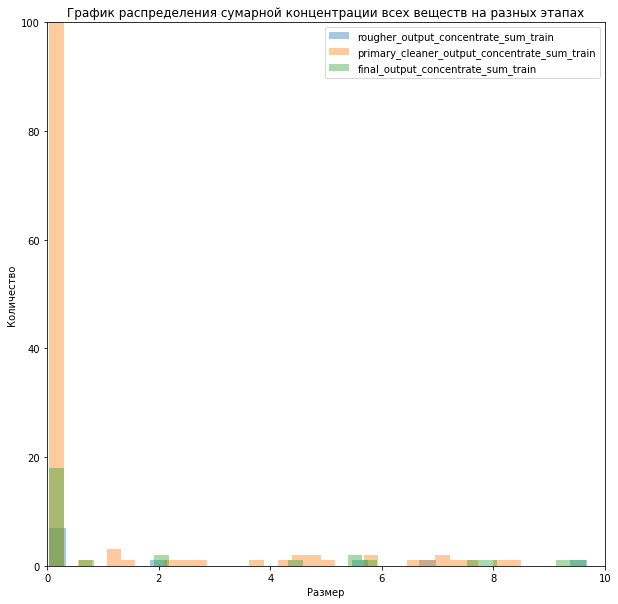

```python
plt.figure(figsize=[10,10])

plt.hist(rougher_output_concentrate_sum_train, bins=300, label = 'rougher_output_concentrate_sum_train', alpha=0.4)
plt.hist(primary_cleaner_output_concentrate_sum_train, bins=300, label = 'primary_cleaner_output_concentrate_sum_train', alpha=0.4)
plt.hist(final_output_concentrate_sum_trаin, bins=300, label = 'final_output_concentrate_sum_trаin', alpha=0.4)



plt.xlim([0, 10])
plt.ylim([0, 100])
plt.xlabel("Размер")
plt.ylabel("Количество")
plt.title("График распределения сумарнoй концентрации всех веществ на разных этапах")
plt.legend()
```

### Conclusion:

# 3. Model.

First, let's organize and prepare the data.

```python
target_train_final = df_train['final.output.recovery']
target_train_rougher = df_train['rougher.output.recovery']

features_column = df_test.columns
df_train = df_train[features_column]
```

```python
target_test_rougher = df.loc[df_test.index,'rougher.output.recovery']
target_test_final = df.loc[df_test.index,'final.output.recovery']
```

Let's write a function to calculate the final sMAPE ("symmetric mean absolute percentage deviation")

```python
def sMAPE(rougher_recovery_real, rougher_recovery_predicted, final_recovery_real, final_recovery_predicted):
    N = rougher_recovery_real.shape[0]
    sMAPE_rougher = ((2*abs(rougher_recovery_real - rougher_recovery_predicted)/
                     (abs(rougher_recovery_real) + abs(rougher_recovery_predicted))).sum() * 100 / N)
    sMAPE_final = ((2*abs(final_recovery_real - final_recovery_predicted)/
                     (abs(final_recovery_real) + abs(final_recovery_predicted))).sum() * 100 / N)
    return sMAPE_rougher * 0.25 + sMAPE_final * 0.75
```

```python
train_nans = df_train.isna().any(axis=1) | target_train_rougher.isna() | target_train_final.isna()
test_nans = df_test.isna().any(axis=1) | target_test_rougher.isna() | target_test_final.isna()

df_train = df_train[~train_nans]
target_train_rougher = target_train_rougher[~train_nans]
target_train_final = target_train_final[~train_nans]

df_test = df_test[~test_nans]
target_test_rougher = target_test_rougher[~test_nans]
target_test_final = target_test_final[~test_nans]
```

First, let's try to train a linear regression model on a training set and find sMAPE, as well as evaluate the quality of the model by cross-validation.

```python
def Smape (target, predicted):
    return 100 / len(target) * np.sum(2 * np.abs(target - predicted) / (np.abs(target) + np.abs(predicted)))
```

```python
def Smape_final(Smape_1, Smape_2):
    return Smape_1 * 0.25 + Smape_2 * 0.75
```

```python
model = LinearRegression()
score = cross_val_score(model, df_train, target_train_rougher, cv = 5, scoring = make_scorer(Smape))
final_score_rougher = score.mean()
display(final_score_rougher)
```

```
6.905053098741286
```

```python
model_final = LinearRegression()
score_final = cross_val_score(model_final, df_train, target_train_final, cv = 5, scoring = make_scorer(Smape))
final_score_final = score_final.mean()
display(final_score_final)
```

```
10.241993078908724
```

```python
Smape_final(final_score_rougher, final_score_final)
```

```
9.407758083866865
```

Let's build a random forest model.

```python
model_2 = RandomForestRegressor(random_state = 12345, max_depth= 5)
score_2 = cross_val_score(model_2, df_train, target_train_rougher, cv = 5, scoring = make_scorer(Smape))
final_score_rougher_2 = score_2.mean()
display(final_score_rougher_2)
```

```
5.87000162176285
```

```python
model_final_2 = RandomForestRegressor(random_state = 12345, max_depth= 5)
score_final_2 = cross_val_score(model_final_2, df_train, target_train_final, cv = 5, scoring = make_scorer(Smape))
final_score_final_2 = score_final_2.mean()
display(final_score_final_2)
```

```
8.63369433225512
```

```python
Smape_final(final_score_rougher_2, final_score_final_2)
```

```
7.9427711546320525
```

Let's build a decision tree model.

```python
for depth in range(2, 10):
    model_3 = DecisionTreeRegressor(random_state = 12345, max_depth= depth)
    score_3 = cross_val_score(model_3, df_train, target_train_rougher, cv = 5, scoring = make_scorer(Smape))
    final_score_rougher_3 = score_3.mean()
    display(final_score_rougher_3)
```

```
6.746697927119262
```

```
7.347138689103156
```

```
6.751538335052142
```

```
6.713342731480674
```

```
6.5934974039492005
```

```
6.91579933731275
```

```
7.584223999730381
```

```
7.440650140231227
```

```python
for depth in range(2, 10):
    model_final_3 = DecisionTreeRegressor(random_state = 12345, max_depth= depth)
    score_final_3 = cross_val_score(model_final_3, df_train, target_train_final, cv = 5, scoring = make_scorer(Smape))
    final_score_final_3 = score_final_3.mean()
    display(final_score_final_3)
```

```
9.220507170606021
```

```
9.168273357829872
```

```
9.226425543854198
```

```
10.343051527414719
```

```
10.330659069529409
```

```
11.875215622961326
```

```
13.562477365382245
```

```
12.782693560720443
```

```python
model_3 = DecisionTreeRegressor(random_state = 12345, max_depth= 5)
score_3 = cross_val_score(model_3, df_train, target_train_rougher, cv = 5, scoring = make_scorer(Smape))
final_score_rougher_3 = score_3.mean()
display(final_score_rougher_3)
```

```
6.713342731480674
```

```python
model_final_3 = DecisionTreeRegressor(random_state = 12345, max_depth= 3)
score_final_3 = cross_val_score(model_final_3, df_train, target_train_final, cv = 5, scoring = make_scorer(Smape))
final_score_final_3 = score_final_3.mean()
display(final_score_final_3)
```

```
9.168273357829872
```

```python
Smape_final(final_score_rougher_3, final_score_final_3)
```

```
8.554540701242573
```

The best model is the random forest model. Let's check it on a test sample:

```python
model = RandomForestRegressor(random_state = 12345, max_depth= 5)
model.fit(df_train, target_train_rougher)
predicted_test_rougher = model.predict(df_test)

model.fit(df_train, target_train_final)
predicted_test_final = model.predict(df_test)

sMAPE(target_test_rougher, predicted_test_rougher, target_test_final, predicted_test_final)
```

```
8.979082540043157
```

### Conclusion:

Next, we wrote a function to calculate the final sMAPE (symmetric mean absolute percentage deviation) and trained different models, evaluating their quality by cross-validation. The random forest model showed the best result and it was it that was tested on the test sample, obtaining sMAPE equal to 8.97.